# 📌 Extract: O E do ETL

# 📌 Transform: Depois Enriquecer

## 1️⃣ Ao nível de colunas

### 💡 Coluna Condicional ou Personalizada

```python
df_receitas.columns
```

```
Index(['atendimento_id', 'data_lancamento', 'receita_codigo',
       'venda_quantidade', 'venda_valor', 'cliente_id', 'cliente_sexo',
       'cliente_nascimento_data', 'cliente_origem',
       'profissional_especialidade', 'pagamento_data', 'pagamento_forma'],
      dtype='object')
```

🔹 Se tivermos uma coluna de data de nascimento, podemos calcular a idade subtraindo do ano atual. Diferente das planilhas não é uma questão de subtração simples, porque data não é tratada como número

```python
from datetime import datetime

# Criando a coluna de idade baseada na data de nascimento. Pegamos o ano atual e subtraímos o ano de nascimento, obtendo a idade.
df_receitas["cliente_idade"] = datetime.today().year - pd.to_datetime(df_receitas["cliente_nascimento_data"]).dt.year
```

```python
df_receitas["cliente_idade"].value_counts()
```

| cliente_idade | count |
| --- | --- |
| 43.0 | 59 |
| 35.0 | 48 |
| 36.0 | 48 |
| 32.0 | 46 |
| 34.0 | 43 |
| ... | ... |
| 84.0 | 1 |
| 78.0 | 1 |
| 14.0 | 1 |
| 11.0 | 1 |
| 86.0 | 1 |

69 rows × 1 columns

**dtype:** int64

```python
# Criando categorias de idade com pd.cut()

df_receitas["cliente_faixa_etaria"] = pd.cut(
    df_receitas["cliente_idade"],
    bins=[0, 17, 35, 60, 100],  # Limites das faixas etárias
    labels=["0-17", "18-35", "36-60", "61-100"]
)
```

```python
df_receitas["cliente_faixa_etaria"].value_counts(dropna=False)
```

| cliente_faixa_etaria | count |
| --- | --- |
| 36-60 | 580 |
| 18-35 | 422 |
| 61-100 | 130 |
| NaN | 103 |
| 0-17 | 7 |

**dtype:** int64

🔹 Existem muitos caminhos. Poderíamos ter usado o np.select novamente para isso

```python
# Criando condições para as faixas etárias
condicoes = [
    df_receitas["cliente_idade"] < 18,
    (df_receitas["cliente_idade"] >= 18) & (df_receitas["cliente_idade"] <= 35),
    (df_receitas["cliente_idade"] > 35) & (df_receitas["cliente_idade"] <= 60),
    df_receitas["cliente_idade"] > 60
]

# 📌 Definindo os rótulos correspondentes
categorias = ["0-17", "18-35", "36-60", "61-100"]

# 📌 Criando a nova coluna com np.select()
df_receitas["cliente_faixa_etaria"] = np.select(condicoes, categorias, default="Desconhecido")
```

```python
df_receitas["cliente_faixa_etaria"].value_counts(dropna=False)
```

| cliente_faixa_etaria | count |
| --- | --- |
| 36-60 | 580 |
| 18-35 | 422 |
| 61-100 | 130 |
| Desconhecido | 103 |
| 0-17 | 7 |

**dtype:** int64

Isso é o que chamamos de **feature engeniier ou engenharia de features**, uma habilidade especialmente importante

### 💡 Aplicando funções

No entanto, pode ser que a criação de features necessite de algum cálculo mais complexo. Um método muito usado na manipulação de dados é aplicar uma função nos dados ou em parte deles, para isso o método **`.apply()`** é muito utilizado.

Importante dizer que esse método **aplica uma determinada função em apenas uma coluna ou linha do DF.**

```python
# Função para categorizar a idade
def classificar_faixa_etaria(idade):
    if idade < 18:
        return "0-17"
    elif idade <= 35:
        return "18-35"
    elif idade <= 60:
        return "36-60"
    elif idade > 60:
        return "61-100"
    else:
        return "Desconhecido"
```

```python
# Aplicando a função com apply()
df_receitas["cliente_faixa_etaria"] = df_receitas["cliente_idade"].apply(classificar_faixa_etaria)
```

**Comparações**

| Critério | `np.select()` | `apply()` com função |
| --- | --- | --- |
| 🔄 **Velocidade** | ✅ Mais rápido para grandes volumes de dados | ❌ Mais lento (loop interno por linha) |
| 🧠 **Clareza e lógica** | ❌ Pode ser menos legível com muitas condições complexas | ✅ Mais legível, fácil de entender |
| 🧩 **Flexibilidade** | ❌ Limitado a expressões booleanas simples | ✅ Pode usar qualquer lógica Python |
| 🛠️ **Engenharia de features** | ✅ Ideal para regras simples de classificação | ✅ Ideal para regras complexas e condicionais encadeadas |
| 🔍 **Depuração e testes** | ❌ Mais difícil de testar e isolar erros | ✅ Função independente facilita testes |

## 2️⃣ Ao nível da tabela

### 💡 Junção de tabelas (Join / Merge)

Em planilhas, utilizamos o velho e bom PROCV, não é mesmo? Mas com essa função em planihas temos pouco controle

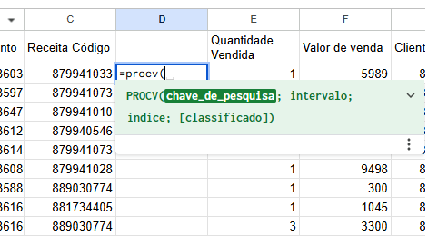

Em nossas aulas gravadas e agora também para o curso síncrono, incluímos a discussão do conceito de Join, que podemos utilizar com mais liberdade em programação Python

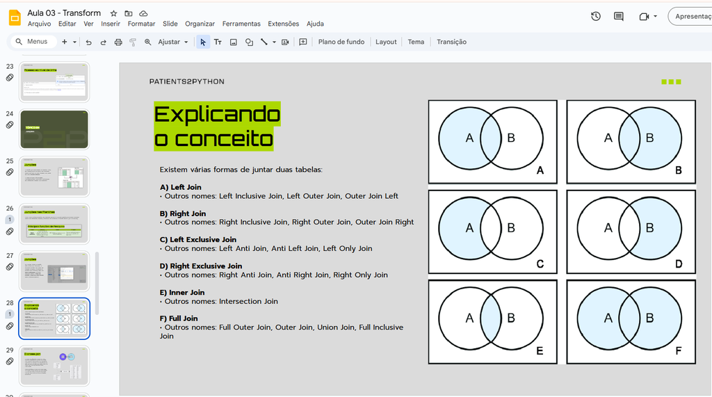

#### 🧐 Teoria

A primeira função a ser trabalhada para junções chama-se **`.merge()`** e tem por objetivo cruzar informações de dois DataFrames relacionados, unindo suas informações em um único DataFrame, possibilitando o acesso às informações de maneira prática.

Muito confuso?? Calma!! Então, vamos aprender a unir DataFrames, começando por criar 2 DataFrames utilizando dicionários:

```python
esquerda = pd.DataFrame({'chave': range(5),
                           'valor_esquerda': ['a', 'b', 'c', 'd', 'e']})
direita = pd.DataFrame({'chave': range(2, 7),
                           'valor_direita': ['f', 'g', 'h', 'i', 'j']})

#Perceba que os dois DataFrames terão diferentes valores de chaves do dicionário, um de 0 a 5 e o outro de 2 a 7
```

```python
esquerda
```

|  | chave | valor_esquerda |
| --- | --- | --- |
| 0 | 0 | a |
| 1 | 1 | b |
| 2 | 2 | c |
| 3 | 3 | d |
| 4 | 4 | e |

```python
direita
```

|  | chave | valor_direita |
| --- | --- | --- |
| 0 | 2 | f |
| 1 | 3 | g |
| 2 | 4 | h |
| 3 | 5 | i |
| 4 | 6 | j |

##### 🚩 **INNER JOIN**

A partir desses 2 DataFrames, podemos notar que existe uma coluna em comum - a coluna 'chave' - que relaciona os dois. A nossa intenção é unir as informações de cada DF cuja 'chave' tenha o mesmo valor. Para isso, usaremos o inner join.

Lembra de conjuntos? Esse comando é como a **intersecção** de dois conjuntos - apenas as informações que pertecem aos dois!

```python
pd.merge(esquerda, direita, on='chave', how='inner')

#Os únicos valores comuns nas chaves são 2, 3 e 4. Portanto, nosso merge só terá essas linhas.
```

|  | chave | valor_esquerda | valor_direita |
| --- | --- | --- | --- |
| 0 | 2 | c | f |
| 1 | 3 | d | g |
| 2 | 4 | e | h |

##### 🚩 **LEFT OUTER JOIN**

A diferença dessa função para a anterior é que agora o programa vai pegar e retornar todas as chaves do DataFrame da esquerda, já no da direita, só vai retornar os valores que existirem no da esquera. Caso não exista, retornará com `NaN`.

```python
pd.merge(esquerda, direita, on='chave', how='left')
```

|  | chave | valor_esquerda | valor_direita |
| --- | --- | --- | --- |
| 0 | 0 | a | NaN |
| 1 | 1 | b | NaN |
| 2 | 2 | c | f |
| 3 | 3 | d | g |
| 4 | 4 | e | h |

##### 🚩 **RIGHT OUTER JOIN**

Análogo ao `merge` anterior, a ideia desse é pegar as chaves do DF da direita, verificar quais chaves existem na esquerda e, assim, devolver os respectivos valores.

```python
pd.merge(esquerda, direita, on='chave', how='right')
```

|  | chave | valor_esquerda | valor_direita |
| --- | --- | --- | --- |
| 0 | 2 | c | f |
| 1 | 3 | d | g |
| 2 | 4 | e | h |
| 3 | 5 | NaN | i |
| 4 | 6 | NaN | j |

Talvez você seja ligeiro(a) e já tenha entendido esse negócio de left e right, mas talvez não. E como nós somos muuuuuuuuito didáticos, vamos explicar:

**Como que o programa sabe quem é `left` e quem é `right`, ali como parâmetro do `how`?**

É bem óbvio, mesmo: o DataFrame referenciado primeiro, dentro de `pd.merge`, está à esquerda do DF referênciado em seguida. Ou seja, o `how='left'` está se referindo ao primeiro DF (Por isso, no nosso exemplo, chamamos o DataFrame de 'esquerda')

Perceba que se trocarmos a ordem e colocarmos o DataFrame 'direita' à esquerda do DataFrame 'esquerda', teremos exatamente o contrário e, portanto, ao usar `how='left'` na verdade ele estará referenciando o DataFrame 'direita'

```python
pd.merge(direita, esquerda, on='chave', how='right')
```

|  | chave | valor_direita | valor_esquerda |
| --- | --- | --- | --- |
| 0 | 0 | NaN | a |
| 1 | 1 | NaN | b |
| 2 | 2 | f | c |
| 3 | 3 | g | d |
| 4 | 4 | h | e |

##### **🚩 FULL OUTER JOIN**

Por fim, essa última forma de `join` basicamente pega todas as chaves existentes em um **ou** outro DataFrame e, com isso, constrói um terceiro com todas elas, havendo conexão entre os DFs ou não.

Esse aqui pode ser comparado com a **união** de dois conjuntos!

```python
pd.merge(esquerda, direita, on='chave', how='outer')
```

|  | chave | valor_esquerda | valor_direita |
| --- | --- | --- | --- |
| 0 | 0 | a | NaN |
| 1 | 1 | b | NaN |
| 2 | 2 | c | f |
| 3 | 3 | d | g |
| 4 | 4 | e | h |
| 5 | 5 | NaN | i |
| 6 | 6 | NaN | j |

##### **🚩 COMBINING**

Existe, ainda, uma forma de juntar esses 2 DataFrames sem fazer a conexão entre as chaves existentes em ambos. É como se você simplesmente "costurasse" um DataFrame no outro.

```python
pd.concat([esquerda, direita])
```

|  | chave | valor_esquerda | valor_direita |
| --- | --- | --- | --- |
| 0 | 0 | a | NaN |
| 1 | 1 | b | NaN |
| 2 | 2 | c | NaN |
| 3 | 3 | d | NaN |
| 4 | 4 | e | NaN |
| 0 | 2 | NaN | f |
| 1 | 3 | NaN | g |
| 2 | 4 | NaN | h |
| 3 | 5 | NaN | i |
| 4 | 6 | NaN | j |

E você pode preferir "costurar" esses DFs de lado. Tudo bem! Olha só:

```python
pd.concat([esquerda, direita], axis=1)
```

|  | chave | valor_esquerda | chave | valor_direita |
| --- | --- | --- | --- | --- |
| 0 | 0 | a | 2 | f |
| 1 | 1 | b | 3 | g |
| 2 | 2 | c | 4 | h |
| 3 | 3 | d | 5 | i |
| 4 | 4 | e | 6 | j |

#### ⚽ Prática

🔹 Basta passar os dataframes que quer juntar e as chaves que se quer utilizar para junção, assim como a forma de junção

```python
df_receitas.columns
```

```
Index(['atendimento_id', 'data_lancamento', 'receita_codigo',
       'venda_quantidade', 'venda_valor', 'cliente_id', 'cliente_sexo',
       'cliente_nascimento_data', 'cliente_origem',
       'profissional_especialidade', 'pagamento_data', 'pagamento_forma',
       'cliente_idade', 'cliente_faixa_etaria'],
      dtype='object')
```

```python
df_receitas.dtypes
```

|  | 0 |
| --- | --- |
| atendimento_id | object |
| data_lancamento | datetime64[ns] |
| receita_codigo | object |
| venda_quantidade | int64 |
| venda_valor | float64 |
| cliente_id | object |
| cliente_sexo | object |
| cliente_nascimento_data | datetime64[ns] |
| cliente_origem | object |
| profissional_especialidade | object |
| pagamento_data | datetime64[ns] |
| pagamento_forma | object |
| cliente_idade | float64 |
| cliente_faixa_etaria | object |

**dtype:** object

```python
df_receitas_tipo.columns
```

```
Index(['Código', 'Categoria', 'Nome', 'Imposto', 'Valor Sugerido',
       'Custo Unitário', 'Porcentagem Clínica'],
      dtype='object')
```

```python
df_receitas_tipo.dtypes
```

|  | 0 |
| --- | --- |
| Código | int64 |
| Categoria | object |
| Nome | object |
| Imposto | float64 |
| Valor Sugerido | float64 |
| Custo Unitário | float64 |
| Porcentagem Clínica | float64 |

**dtype:** object

```python
df_final = pd.merge(df_receitas, df_receitas_tipo, left_on="receita_codigo", right_on="Código", how="left", indicator=True)
```

[output not shown]

🔹 Lembre-se (falamos disso!), só é possível utilizar chaves de mesma tipologia. Mas isso não é problema, já sabemos mudar a tipologia

```python
df_receitas_tipo['Código'] = df_receitas_tipo['Código'].astype(str)
```

```python
df_final = pd.merge(df_receitas, df_receitas_tipo, left_on="receita_codigo", right_on="Código", how="left", indicator=True)
```

```python
df_final.columns
```

```
Index(['atendimento_id', 'data_lancamento', 'receita_codigo',
       'venda_quantidade', 'venda_valor', 'cliente_id', 'cliente_sexo',
       'cliente_nascimento_data', 'cliente_origem',
       'profissional_especialidade', 'pagamento_data', 'pagamento_forma',
       'cliente_idade', 'cliente_faixa_etaria', 'Código', 'Categoria', 'Nome',
       'Imposto', 'Valor Sugerido', 'Custo Unitário', 'Porcentagem Clínica',
       '_merge'],
      dtype='object')
```

```python
df_final['_merge'].value_counts()
```

| _merge | count |
| --- | --- |
| both | 1242 |
| left_only | 0 |
| right_only | 0 |

**dtype:** int64

```python
df_final.columns
```

```
Index(['atendimento_id', 'data_lancamento', 'receita_codigo',
       'venda_quantidade', 'venda_valor', 'cliente_id', 'cliente_sexo',
       'cliente_nascimento_data', 'cliente_origem',
       'profissional_especialidade', 'pagamento_data', 'pagamento_forma',
       'cliente_idade', 'cliente_faixa_etaria', 'Código', 'Categoria', 'Nome',
       'Imposto', 'Valor Sugerido', 'Custo Unitário', 'Porcentagem Clínica',
       '_merge'],
      dtype='object')
```

```python
df_final.head(5)
```

[output not shown]

```python
df_final['nome_data_atrapalhado'] = df_final['cliente_id'].astype(str) + "_" + df_final['cliente_nascimento_data'].astype(str)
```

```python
df_final['nome_data_atrapalhado'].value_counts()
```

| nome_data_atrapalhado | count |
| --- | --- |
| 881735998_1982-08-04 | 27 |
| 881735885_1958-10-20 | 17 |
| 917317600_1995-06-22 | 11 |
| 881736740_1981-02-17 | 11 |
| 881736934_1970-06-20 | 11 |
| ... | ... |
| 881737490_1991-04-29 | 1 |
| 881737510_1996-03-05 | 1 |
| 881737488_1960-11-17 | 1 |
| 881737485_1977-09-14 | 1 |
| 881737377_1972-04-19 | 1 |

682 rows × 1 columns

**dtype:** int64

```python
# prompt: faça uma separação do dado nome_data_atrapalhado através do "_"

# Assuming df_final is already defined as in the provided code.
df_final[['cliente_id', 'cliente_nascimento_data']] = df_final['nome_data_atrapalhado'].str.split('_', expand=True)
```

```python
df_final.head(3).T
```

|  | 0 | 1 | 2 |
| --- | --- | --- | --- |
| atendimento_id | 45443933211803 | 45443913709155 | 45441923179337 |
| data_lancamento | 2024-05-31 00:00:00 | 2024-05-31 00:00:00 | 2024-05-29 00:00:00 |
| receita_codigo | 881732900 | 881732900 | 879938579 |
| venda_quantidade | 1 | 1 | 1 |
| venda_valor | 250.0 | 250.0 | 1500.0 |
| cliente_id | 933211803 | 913709155 | 923179337 |
| cliente_sexo | Feminino | Feminino | Feminino |
| cliente_nascimento_data | 1998-01-26 | 1995-08-01 | 1977-12-27 |
| cliente_origem | NaN | NaN | Rede Social |
| profissional_especialidade | Cirurgia Plástica | Cirurgia Plástica | Cirurgia Plástica |
| pagamento_data | 2024-06-12 00:00:00 | 2024-06-12 00:00:00 | 2024-06-28 00:00:00 |
| pagamento_forma | Pix | Pix | Cartão de crédito à vista |
| cliente_idade | 27.0 | 30.0 | 48.0 |
| cliente_faixa_etaria | 18-35 | 18-35 | 36-60 |
| Código | 881732900 | 881732900 | 879938579 |
| Categoria | Consulta | Consulta | Cirurgia ambulatorial |
| Nome | Consulta Cirurgia Plástica | Consulta Cirurgia Plástica | Pequena Cirurgia |
| Imposto | 0.12 | 0.12 | 0.08 |
| Valor Sugerido | 300.0 | 300.0 | 1500.0 |
| Custo Unitário | 30.0 | 30.0 | 612.6 |
| Porcentagem Clínica | 0.3 | 0.3 | 0.3 |
| _merge | both | both | both |
| nome_data_atrapalhado | 933211803_1998-01-26 | 913709155_1995-08-01 | 923179337_1977-12-27 |

```python
df_receitas.shape
```

```
(1242, 14)
```

```python
df_final.shape
```

```
(1242, 23)
```

[Clique para consultar a documentação](https://pandas.pydata.org/docs/reference/api/pandas.merge.html)

### 💡 Agregações

🔹 Podemos utilizar a função groupby, muito conhecida do SQL. Passe as colunas pelas quais quer agregar (como dimensão). As colunas que quer agregar (como fato) e a forma de agregação

#### 🧐 Teoria

Presta atenção aqui! Para usar essa função, precisamos entender algumas coisinhas, pois o groupby() funciona em três etapas — pense como um processo de fábrica

| Etapa | O que acontece | Exemplo |
| --- | --- | --- |
| **Dividir** | Divide os dados em grupos, com base em uma ou mais colunas | Agrupar por sexo, curso, cidade... |
| **Aplicar** | Aplica uma função em cada grupo (ex: média, soma, contagem, etc) | Média de notas, soma de vendas, etc. |
| **Combinar** | Junta os resultados em uma nova tabela, organizada por grupo | Mostra os resultados lado a lado |

```python
import pandas as pd

# Criando a tabela (DataFrame)
dados = pd.DataFrame({
    'Aluno': ['Ana', 'Bruno', 'Carla', 'Daniel'],
    'Sexo': ['F', 'M', 'F', 'M'],
    'Turma':['Turma A', 'Turma A', 'Turma B', 'Turma B'],
    'Nota': [8.5, 7.0, 9.0, 6.5]
})
```

```python
dados
```

|  | Aluno | Sexo | Turma | Nota |
| --- | --- | --- | --- | --- |
| 0 | Ana | F | Turma A | 8.5 |
| 1 | Bruno | M | Turma A | 7.0 |
| 2 | Carla | F | Turma B | 9.0 |
| 3 | Daniel | M | Turma B | 6.5 |

```python
dados.groupby('Sexo')['Nota'].mean()
```

| Sexo | Nota |
| --- | --- |
| F | 8.75 |
| M | 6.75 |

**dtype:** float64

Explicação:

- dados.groupby('Sexo') # Agrupa as linhas por valores iguais na coluna 'Sexo'
- ['Nota'] # Escolhe a coluna numérica onde será feita a operação
- .mean() # Aplica a média a cada grupo

**Se você quiser agrupar por mais de uma coisa:**

```python
dados.groupby(['Sexo', 'Turma'])['Nota'].mean()
```

| Sexo | Turma | Nota |
| --- | --- | --- |
| F | Turma A | 8.5 |
|  | Turma B | 9.0 |
| M | Turma A | 7.0 |
|  | Turma B | 6.5 |

**dtype:** float64

**Se você quiser calcular mais de uma medida:**

```python
dados.groupby("Sexo")["Nota"].agg(["mean", "min"])
```

| Sexo | mean | min |
| --- | --- | --- |
| F | 8.75 | 8.5 |
| M | 6.75 | 6.5 |

```python
dados.groupby("Sexo")["Nota"].aggregate(["mean", "min"])
```

| Sexo | mean | min |
| --- | --- | --- |
| F | 8.75 | 8.5 |
| M | 6.75 | 6.5 |

No Pandas, .agg() e .aggregate() são exatamente a mesma coisa. A diferença está somente no nome — ambas as funções fazem a mesma operação.

**Se você quiser agregar calculando uma função também é possível:**

👩‍🏫 Às vezes, queremos fazer mais do que só calcular uma média, soma ou contagem. A função .apply() permite aplicar qualquer lógica personalizada em cada grupo!

```python
def classificar_grupo(grupo):
    media = grupo["Nota"].mean()
    if media > 8:
        return "Excelente"
    elif media >= 6:
        return "Regular"
    else:
        return "Ruim"

# Aplicando por grupo de Sexo
dados.groupby("Sexo").apply(classificar_grupo)
```

| Sexo | 0 |
| --- | --- |
| F | Excelente |
| M | Regular |

**dtype:** object

```python
df.groupby(coluna_agrupadora)["coluna_valor"].função()
```

```python
df.groupby("Sexo")["Nota"].mean()
```

```python
df.groupby(["Sexo", "Turma"])["Nota"].mean()
```

```python
df.groupby("Sexo")["Nota"].agg(["mean", "min"])
```

```python
df.groupby("Sexo")["Nota"].aggregate(["mean", "min"])
```

```python
def classificar_grupo(grupo):
    media = grupo["Nota"].mean()
    if media > 8:
        return "Excelente"
    elif media >= 6:
        return "Regular"
    else:
        return "Ruim"

df.groupby("Sexo").apply(classificar_grupo)
```

#### ⚽ Prática

```python
df_agrupado = df_final.groupby(["cliente_sexo", "pagamento_forma"])["venda_valor"].sum()
```

```python
df_agrupado
```

[output not shown]

**dtype:** float64

```python
df_agrupado.reset_index()
```

[output not shown]

🔹 Mas essa função pode ser bem flexível

```python
df_final.columns
```

```
Index(['atendimento_id', 'data_lancamento', 'receita_codigo',
       'venda_quantidade', 'venda_valor', 'cliente_id', 'cliente_sexo',
       'cliente_nascimento_data', 'cliente_origem',
       'profissional_especialidade', 'pagamento_data', 'pagamento_forma',
       'cliente_idade', 'cliente_faixa_etaria', 'Código', 'Categoria', 'Nome',
       'Imposto', 'Valor Sugerido', 'Custo Unitário', 'Porcentagem Clínica',
       '_merge', 'nome_data_atrapalhado'],
      dtype='object')
```

```python
# Definição das colunas para agrupamento
colunas_agregantes = ["cliente_sexo", "profissional_especialidade"]

# Dicionário de agregações dinâmico
dicionario_valores_agregados = {
    "venda_valor": ["sum", "mean", "max", "min"],
    "pagamento_data": ["min", "max"]
}

# Aplicando o agrupamento e agregações
df_agregado = df_final.groupby(colunas_agregantes).aggregate(dicionario_valores_agregados)
```

```python
df_agregado
```

| cliente_sexo | profissional_especialidade | venda_valor sum | venda_valor mean | venda_valor max | venda_valor min | pagamento_data min | pagamento_data max |
| --- | --- | --- | --- | --- | --- | --- | --- |
| Feminino | Cirurgia Plástica | 610401.62 | 1253.391417 | 20217.40 | 0.00 | 2021-10-21 | 2024-07-05 |
|  | Dermatologia | 189326.98 | 1168.685062 | 6750.00 | 200.00 | 2022-03-03 | 2024-06-20 |
|  | Educador Físico | 200.00 | 200.000000 | 200.00 | 200.00 | 2023-06-19 | 2023-06-19 |
|  | Ginecologia | 105129.59 | 503.012392 | 3000.00 | 0.00 | 2022-04-13 | 2024-06-14 |
|  | Nutricionista | 1500.00 | 214.285714 | 250.00 | 200.00 | 2023-06-04 | 2024-06-16 |
|  | Nutrologia | 96605.00 | 1380.071429 | 4200.00 | 582.00 | 2022-03-07 | 2024-06-16 |
|  | Psicólogo | 4300.00 | 537.500000 | 900.00 | 200.00 | 2023-05-08 | 2024-06-17 |
| Masculino | Cirurgia Plástica | 58635.83 | 1628.773056 | 14066.43 | 123.00 | 2021-11-30 | 2024-04-29 |
|  | Dermatologia | 27520.00 | 688.000000 | 2375.00 | 240.00 | 2022-03-23 | 2024-04-02 |
|  | Ginecologia | 650.00 | 325.000000 | 350.00 | 300.00 | 2022-07-03 | 2023-03-04 |
|  | Nutricionista | 400.00 | 200.000000 | 200.00 | 200.00 | 2023-12-08 | 2024-01-17 |
|  | Nutrologia | 33990.50 | 1477.847826 | 3000.00 | 600.00 | 2022-03-04 | 2024-03-17 |
|  | Psicólogo | 1000.00 | 333.333333 | 600.00 | 200.00 | 2023-06-21 | 2024-04-01 |
| Não informado | Cirurgia Plástica | 207837.56 | 2057.797624 | 15695.00 | 53.20 | 2022-03-21 | 2024-04-28 |
|  | Dermatologia | 15300.00 | 765.000000 | 2200.00 | 400.00 | 2022-04-01 | 2024-02-02 |
|  | Fisioterapeuta | 600.00 | 600.000000 | 600.00 | 600.00 | 2024-02-26 | 2024-02-26 |
|  | Ginecologia | 23860.03 | 433.818727 | 3000.00 | 84.56 | 2022-05-29 | 2024-05-11 |
|  | Nutrologia | 12154.50 | 934.961538 | 1950.00 | 600.00 | 2022-04-15 | 2024-02-02 |
|  | Psicólogo | 800.00 | 400.000000 | 600.00 | 200.00 | 2023-05-27 | 2023-06-20 |

### 💡 Multi-índices

#### 🧐 Teoria

A estrutura formada previamente é o que se chama de multi-índices. A ideia de multi-indíces (ou multi-index) é mais intuitiva quando pensamos em Excel. Sabe a função "mesclar células"?

Então, vamos para um exemplo

```python
notas_listas_dic = {'aluno':['Maria', 'Augusto', 'Natalia', 'Ricardo', 'Maria', 'Augusto', 'Ricardo', 'Natalia', 'Maria', 'Augusto',
                             'Ricardo', 'Natalia', 'Maria', 'Augusto', 'Ricardo', 'Natalia', 'Ricardo', 'Natalia'],
                    'nota':[9, 2, 6, 7, 0, 3, 5, 10, 0, 7, 10, 8, 1, 7, 10, 3, 9, 6],
                    'quantidade':[1, 3, 3, 4, 1, 5, 1, 3, 4, 4, 5, 2, 4, 2, 2, 5, 4, 4],
                    'semestre':['semestre 1', 'semestre 1', 'semestre 1', 'semestre 1', 'semestre 1', 'semestre 1', 'semestre 1',
                                'semestre 1', 'semestre 1', 'semestre 2', 'semestre 2', 'semestre 2', 'semestre 2', 'semestre 2',
                                'semestre 2', 'semestre 2', 'semestre 2', 'semestre 2']}
```

```python
#Primeiro, convertemos o dicionário para um DataFrame
notas_listas = pd.DataFrame(notas_listas_dic)
notas_listas
```

|  | aluno | nota | quantidade | semestre |
| --- | --- | --- | --- | --- |
| 0 | Maria | 9 | 1 | semestre 1 |
| 1 | Augusto | 2 | 3 | semestre 1 |
| 2 | Natalia | 6 | 3 | semestre 1 |
| 3 | Ricardo | 7 | 4 | semestre 1 |
| 4 | Maria | 0 | 1 | semestre 1 |
| 5 | Augusto | 3 | 5 | semestre 1 |
| 6 | Ricardo | 5 | 1 | semestre 1 |
| 7 | Natalia | 10 | 3 | semestre 1 |
| 8 | Maria | 0 | 4 | semestre 1 |
| 9 | Augusto | 7 | 4 | semestre 2 |
| 10 | Ricardo | 10 | 5 | semestre 2 |
| 11 | Natalia | 8 | 2 | semestre 2 |
| 12 | Maria | 1 | 4 | semestre 2 |
| 13 | Augusto | 7 | 2 | semestre 2 |
| 14 | Ricardo | 10 | 2 | semestre 2 |
| 15 | Natalia | 3 | 5 | semestre 2 |
| 16 | Ricardo | 9 | 4 | semestre 2 |
| 17 | Natalia | 6 | 4 | semestre 2 |

```python
multi_indices = notas_listas.set_index(['semestre', 'aluno'])
multi_indices
```

| semestre | aluno | nota | quantidade |
| --- | --- | --- | --- |
| semestre 1 | Maria | 9 | 1 |
|  | Augusto | 2 | 3 |
|  | Natalia | 6 | 3 |
|  | Ricardo | 7 | 4 |
|  | Maria | 0 | 1 |
|  | Augusto | 3 | 5 |
|  | Ricardo | 5 | 1 |
|  | Natalia | 10 | 3 |
|  | Maria | 0 | 4 |
| semestre 2 | Augusto | 7 | 4 |
|  | Ricardo | 10 | 5 |
|  | Natalia | 8 | 2 |
|  | Maria | 1 | 4 |
|  | Augusto | 7 | 2 |
|  | Ricardo | 10 | 2 |
|  | Natalia | 3 | 5 |
|  | Ricardo | 9 | 4 |
|  | Natalia | 6 | 4 |

Então, veja: um MultiIndex (ou índice hierárquico) é uma maneira de organizar os dados em camadas. Em vez de ter uma única coluna como índice (por exemplo, só aluno), você pode usar duas ou mais colunas como índice ao mesmo tempo (por exemplo, semestre e aluno). Entretanto, diferente do groupby, ele não agrega, apenas organiza. Veja o caso do aluno Ricardo.

| Ação | Código | Explicação breve |
| --- | --- | --- |
| Criar MultiIndex | `df.set_index(['col1', 'col2'])` | Define múltiplas colunas como índice |
| Ver os níveis do índice | `df.index.levels` | Mostra os valores únicos de cada nível |
| Contar níveis | `df.index.nlevels` | Mostra quantos níveis há no índice |
| Resetar o índice | `df.reset_index()` | Transforma o índice em colunas normais |
| Acessar um nível do índice | `df.index.get_level_values(0)` | Retorna os valores do nível 0 (por ex.) |

#### ⚽ Prática

Voltando ao nosso dataframe agrupado final

```python
df_agregado
```

| cliente_sexo | profissional_especialidade | venda_valor sum | venda_valor mean | venda_valor max | venda_valor min | pagamento_data min | pagamento_data max |
| --- | --- | --- | --- | --- | --- | --- | --- |
| Feminino | Cirurgia Plástica | 610401.62 | 1253.391417 | 20217.40 | 0.00 | 2021-10-21 | 2024-07-05 |
|  | Dermatologia | 189326.98 | 1168.685062 | 6750.00 | 200.00 | 2022-03-03 | 2024-06-20 |
|  | Educador Físico | 200.00 | 200.000000 | 200.00 | 200.00 | 2023-06-19 | 2023-06-19 |
|  | Ginecologia | 105129.59 | 503.012392 | 3000.00 | 0.00 | 2022-04-13 | 2024-06-14 |
|  | Nutricionista | 1500.00 | 214.285714 | 250.00 | 200.00 | 2023-06-04 | 2024-06-16 |
|  | Nutrologia | 96605.00 | 1380.071429 | 4200.00 | 582.00 | 2022-03-07 | 2024-06-16 |
|  | Psicólogo | 4300.00 | 537.500000 | 900.00 | 200.00 | 2023-05-08 | 2024-06-17 |
| Masculino | Cirurgia Plástica | 58635.83 | 1628.773056 | 14066.43 | 123.00 | 2021-11-30 | 2024-04-29 |
|  | Dermatologia | 27520.00 | 688.000000 | 2375.00 | 240.00 | 2022-03-23 | 2024-04-02 |
|  | Ginecologia | 650.00 | 325.000000 | 350.00 | 300.00 | 2022-07-03 | 2023-03-04 |
|  | Nutricionista | 400.00 | 200.000000 | 200.00 | 200.00 | 2023-12-08 | 2024-01-17 |
|  | Nutrologia | 33990.50 | 1477.847826 | 3000.00 | 600.00 | 2022-03-04 | 2024-03-17 |
|  | Psicólogo | 1000.00 | 333.333333 | 600.00 | 200.00 | 2023-06-21 | 2024-04-01 |
| Não informado | Cirurgia Plástica | 207837.56 | 2057.797624 | 15695.00 | 53.20 | 2022-03-21 | 2024-04-28 |
|  | Dermatologia | 15300.00 | 765.000000 | 2200.00 | 400.00 | 2022-04-01 | 2024-02-02 |
|  | Fisioterapeuta | 600.00 | 600.000000 | 600.00 | 600.00 | 2024-02-26 | 2024-02-26 |
|  | Ginecologia | 23860.03 | 433.818727 | 3000.00 | 84.56 | 2022-05-29 | 2024-05-11 |
|  | Nutrologia | 12154.50 | 934.961538 | 1950.00 | 600.00 | 2022-04-15 | 2024-02-02 |
|  | Psicólogo | 800.00 | 400.000000 | 600.00 | 200.00 | 2023-05-27 | 2023-06-20 |

```python
df_agregado.index.levels
```

```
FrozenList([['Feminino', 'Masculino', 'Não informado'], ['Cirurgia Plástica', 'Dermatologia', 'Educador Físico', 'Fisioterapeuta', 'Ginecologia', 'Nutricionista', 'Nutrologia', 'Psicólogo']])
```

```python
df_agregado.index.nlevels
```

```
2
```

```python
# Resetando o índice para transformar colunas agregantes em colunas normais
df_agregado = df_agregado.reset_index()
df_agregado
```

|  | cliente_sexo | profissional_especialidade | venda_valor sum | venda_valor mean | venda_valor max | venda_valor min | pagamento_data min | pagamento_data max |
| --- | --- | --- | --- | --- | --- | --- | --- | --- |
| 0 | Feminino | Cirurgia Plástica | 610401.62 | 1253.391417 | 20217.40 | 0.00 | 2021-10-21 | 2024-07-05 |
| 1 | Feminino | Dermatologia | 189326.98 | 1168.685062 | 6750.00 | 200.00 | 2022-03-03 | 2024-06-20 |
| 2 | Feminino | Educador Físico | 200.00 | 200.000000 | 200.00 | 200.00 | 2023-06-19 | 2023-06-19 |
| 3 | Feminino | Ginecologia | 105129.59 | 503.012392 | 3000.00 | 0.00 | 2022-04-13 | 2024-06-14 |
| 4 | Feminino | Nutricionista | 1500.00 | 214.285714 | 250.00 | 200.00 | 2023-06-04 | 2024-06-16 |
| 5 | Feminino | Nutrologia | 96605.00 | 1380.071429 | 4200.00 | 582.00 | 2022-03-07 | 2024-06-16 |
| 6 | Feminino | Psicólogo | 4300.00 | 537.500000 | 900.00 | 200.00 | 2023-05-08 | 2024-06-17 |
| 7 | Masculino | Cirurgia Plástica | 58635.83 | 1628.773056 | 14066.43 | 123.00 | 2021-11-30 | 2024-04-29 |
| 8 | Masculino | Dermatologia | 27520.00 | 688.000000 | 2375.00 | 240.00 | 2022-03-23 | 2024-04-02 |
| 9 | Masculino | Ginecologia | 650.00 | 325.000000 | 350.00 | 300.00 | 2022-07-03 | 2023-03-04 |
| 10 | Masculino | Nutricionista | 400.00 | 200.000000 | 200.00 | 200.00 | 2023-12-08 | 2024-01-17 |
| 11 | Masculino | Nutrologia | 33990.50 | 1477.847826 | 3000.00 | 600.00 | 2022-03-04 | 2024-03-17 |
| 12 | Masculino | Psicólogo | 1000.00 | 333.333333 | 600.00 | 200.00 | 2023-06-21 | 2024-04-01 |
| 13 | Não informado | Cirurgia Plástica | 207837.56 | 2057.797624 | 15695.00 | 53.20 | 2022-03-21 | 2024-04-28 |
| 14 | Não informado | Dermatologia | 15300.00 | 765.000000 | 2200.00 | 400.00 | 2022-04-01 | 2024-02-02 |
| 15 | Não informado | Fisioterapeuta | 600.00 | 600.000000 | 600.00 | 600.00 | 2024-02-26 | 2024-02-26 |
| 16 | Não informado | Ginecologia | 23860.03 | 433.818727 | 3000.00 | 84.56 | 2022-05-29 | 2024-05-11 |
| 17 | Não informado | Nutrologia | 12154.50 | 934.961538 | 1950.00 | 600.00 | 2022-04-15 | 2024-02-02 |
| 18 | Não informado | Psicólogo | 800.00 | 400.000000 | 600.00 | 200.00 | 2023-05-27 | 2023-06-20 |

```python
# 🔹 Formatando os nomes das colunas para facilitar a leitura, retirando o multiindex
df_agregado.columns = [''.join(col).strip() for col in df_agregado.columns.values]
df_agregado
```

|  | cliente_sexo | profissional_especialidade | venda_valorsum | venda_valormean | venda_valormax | venda_valormin | pagamento_datamin | pagamento_datamax |
| --- | --- | --- | --- | --- | --- | --- | --- | --- |
| 0 | Feminino | Cirurgia Plástica | 610401.62 | 1253.391417 | 20217.40 | 0.00 | 2021-10-21 | 2024-07-05 |
| 1 | Feminino | Dermatologia | 189326.98 | 1168.685062 | 6750.00 | 200.00 | 2022-03-03 | 2024-06-20 |
| 2 | Feminino | Educador Físico | 200.00 | 200.000000 | 200.00 | 200.00 | 2023-06-19 | 2023-06-19 |
| 3 | Feminino | Ginecologia | 105129.59 | 503.012392 | 3000.00 | 0.00 | 2022-04-13 | 2024-06-14 |
| 4 | Feminino | Nutricionista | 1500.00 | 214.285714 | 250.00 | 200.00 | 2023-06-04 | 2024-06-16 |
| 5 | Feminino | Nutrologia | 96605.00 | 1380.071429 | 4200.00 | 582.00 | 2022-03-07 | 2024-06-16 |
| 6 | Feminino | Psicólogo | 4300.00 | 537.500000 | 900.00 | 200.00 | 2023-05-08 | 2024-06-17 |
| 7 | Masculino | Cirurgia Plástica | 58635.83 | 1628.773056 | 14066.43 | 123.00 | 2021-11-30 | 2024-04-29 |
| 8 | Masculino | Dermatologia | 27520.00 | 688.000000 | 2375.00 | 240.00 | 2022-03-23 | 2024-04-02 |
| 9 | Masculino | Ginecologia | 650.00 | 325.000000 | 350.00 | 300.00 | 2022-07-03 | 2023-03-04 |
| 10 | Masculino | Nutricionista | 400.00 | 200.000000 | 200.00 | 200.00 | 2023-12-08 | 2024-01-17 |
| 11 | Masculino | Nutrologia | 33990.50 | 1477.847826 | 3000.00 | 600.00 | 2022-03-04 | 2024-03-17 |
| 12 | Masculino | Psicólogo | 1000.00 | 333.333333 | 600.00 | 200.00 | 2023-06-21 | 2024-04-01 |
| 13 | Não informado | Cirurgia Plástica | 207837.56 | 2057.797624 | 15695.00 | 53.20 | 2022-03-21 | 2024-04-28 |
| 14 | Não informado | Dermatologia | 15300.00 | 765.000000 | 2200.00 | 400.00 | 2022-04-01 | 2024-02-02 |
| 15 | Não informado | Fisioterapeuta | 600.00 | 600.000000 | 600.00 | 600.00 | 2024-02-26 | 2024-02-26 |
| 16 | Não informado | Ginecologia | 23860.03 | 433.818727 | 3000.00 | 84.56 | 2022-05-29 | 2024-05-11 |
| 17 | Não informado | Nutrologia | 12154.50 | 934.961538 | 1950.00 | 600.00 | 2022-04-15 | 2024-02-02 |
| 18 | Não informado | Psicólogo | 800.00 | 400.000000 | 600.00 | 200.00 | 2023-05-27 | 2023-06-20 |

🔹 Por fim, pode ser que você queira **exportar essa tabela formada**

Para exportar nosso DataFrame manipulado, vamos utilizar a função **`to_csv`** .

```python
df_agregado.to_csv('df_agrupado.csv')
```

```python
df_agregado.to_excel('df_agrupado.xlsx')
```

### 💡 Stack & Unstack

Acabamos de aprender uma forma de organizar o DataFrame em relação ao seu índice, agora vamos dar uma olhadinha em outra maneira de modelar nosso `DataFrame`.

Os métodos **`.stack()`** e **`.unstack()`** podem ser usados tanto em `Series` quanto em `DataFrames` e são usados juntamente com o conceito de `Multi-index` que acabamos de ver.

#### `Stack`

Em português, "empilhar", é um método que, basicamente, empilha os dados do DataFrame em uma ou mais linhas. Ou seja, move colunas para o índice (linha) → deixa o DataFrame mais longo e estreito

```python
#Primeiro vamos criar um DataFrame

colunas = pd.MultiIndex.from_product([['2017', '2018'],['Vendas', 'Clientes']])
df_exemplo=([[12, 45, 67, 56],[78, 89, 45, 67],[45, 67, 89, 90],[67, 44, 56, 55]])


df_exemplo = pd.DataFrame(df_exemplo,
                  index=['Ana', 'Bruno', 'Cristina', 'Jackson'],
                  columns=colunas)
df_exemplo
```

|  | 2017 Vendas | 2017 Clientes | 2018 Vendas | 2018 Clientes |
| --- | --- | --- | --- | --- |
| Ana | 12 | 45 | 67 | 56 |
| Bruno | 78 | 89 | 45 | 67 |
| Cristina | 45 | 67 | 89 | 90 |
| Jackson | 67 | 44 | 56 | 55 |

Aqui temos uma estrutura de colunas com dois níveis:

- Nível 0: ano (2017, 2018)
- Nível 1: tipo de dado (Clientes, Vendas)

Vamos então transformar as colunas do nível 0 em linhas:

```python
empilhado = df_exemplo.stack(0)
empilhado
```

|  |  | Vendas | Clientes |
| --- | --- | --- | --- |
| Ana | 2017 | 12 | 45 |
|  | 2018 | 67 | 56 |
| Bruno | 2017 | 78 | 89 |
|  | 2018 | 45 | 67 |
| Cristina | 2017 | 45 | 67 |
|  | 2018 | 89 | 90 |
| Jackson | 2017 | 67 | 44 |
|  | 2018 | 56 | 55 |

E agora vamos então transformar as colunas do nível 1 em linhas:

```python
empilhado = df_exemplo.stack(1)
empilhado
```

|  |  | 2017 | 2018 |
| --- | --- | --- | --- |
| Ana | Clientes | 45 | 56 |
|  | Vendas | 12 | 67 |
| Bruno | Clientes | 89 | 67 |
|  | Vendas | 78 | 45 |
| Cristina | Clientes | 67 | 90 |
|  | Vendas | 45 | 89 |
| Jackson | Clientes | 44 | 55 |
|  | Vendas | 67 | 56 |

Se não passar o parâmetro, será adotado o nível interno (maior)

```python
empilhado = df_exemplo.stack()
empilhado
```

|  |  | 2017 | 2018 |
| --- | --- | --- | --- |
| Ana | Clientes | 45 | 56 |
|  | Vendas | 12 | 67 |
| Bruno | Clientes | 89 | 67 |
|  | Vendas | 78 | 45 |
| Cristina | Clientes | 67 | 90 |
|  | Vendas | 45 | 89 |
| Jackson | Clientes | 44 | 55 |
|  | Vendas | 67 | 56 |

#### `Unstack`

É o método inverso ao `stack`, ou seja, ele pega os índices interiores de linhas e transforma em índices interiores de colunas. Ou seja, move linhas para colunas → deixa o DataFrame mais curto e longo.

```python
empilhado
```

|  |  | 2017 | 2018 |
| --- | --- | --- | --- |
| Ana | Clientes | 45 | 56 |
|  | Vendas | 12 | 67 |
| Bruno | Clientes | 89 | 67 |
|  | Vendas | 78 | 45 |
| Cristina | Clientes | 67 | 90 |
|  | Vendas | 45 | 89 |
| Jackson | Clientes | 44 | 55 |
|  | Vendas | 67 | 56 |

Aqui temos uma estrutura de índices (linhas) com dois níveis:

- Nível 0: nomes
- Nível 1: tipo de dado (Clientes, Vendas)

Vamos então transformar as linhas do nível 0 em linhas:

```python
desempilhado = empilhado.unstack(0)
desempilhado
```

|  | 2017 Ana | 2017 Bruno | 2017 Cristina | 2017 Jackson | 2018 Ana | 2018 Bruno | 2018 Cristina | 2018 Jackson |
| --- | --- | --- | --- | --- | --- | --- | --- | --- |
| Clientes | 45 | 89 | 67 | 44 | 56 | 67 | 90 | 55 |
| Vendas | 12 | 78 | 45 | 67 | 67 | 45 | 89 | 56 |

E agora vamos então transformar os índices do nível 1 em linhas:

```python
desempilhado = empilhado.unstack(1)
desempilhado
```

|  | 2017 Clientes | 2017 Vendas | 2018 Clientes | 2018 Vendas |
| --- | --- | --- | --- | --- |
| Ana | 45 | 12 | 56 | 67 |
| Bruno | 89 | 78 | 67 | 45 |
| Cristina | 67 | 45 | 90 | 89 |
| Jackson | 44 | 67 | 55 | 56 |

Se não passar o parâmetro, será adotado o nível interno (maior)

```python
desempilhado = empilhado.unstack()
desempilhado
```

|  | 2017 Clientes | 2017 Vendas | 2018 Clientes | 2018 Vendas |
| --- | --- | --- | --- | --- |
| Ana | 45 | 12 | 56 | 67 |
| Bruno | 89 | 78 | 67 | 45 |
| Cristina | 67 | 45 | 90 | 89 |
| Jackson | 44 | 67 | 55 | 56 |

Perceba que o "desempilhado" é o mesmo DataFrame que o original "df". Portanto, o `unstack` desfez o que o `stack` tinha feito, por isso esses dois métodos são como duas operações inversas.

Basicamente, usamos o `stack` quando queremos os dados agrupados em menos colunas e mais linhas, e, caso contrário, usamos o `unstack`.

### 💡 Tabelas Dinâmicas

#### 🧐 Teoria

Em planilhas, utilizamos as boas e velhas Tabelas Dinâmicas, com um suporte do mouse

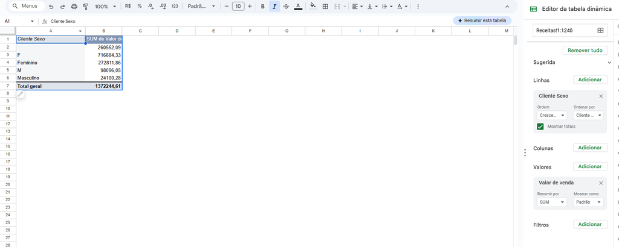

Basicamente, uma `pivot table` é uma tabela com dados retirados de um banco de dados maior, que foram agrupados de maneira significativa para a busca de informações. Ela nos permite organizar e reorganizar os dados para podermos visualizá-los mais facilmente, e também, resumir os dados de forma a retirar as informações realmente importantes e úteis.

Vamos a um exemplo:

```python
sales = [{'conta': 'Jota LLC', 'gerente': 'Artur Nascimento', 'cliente': 'Diego Lima' ,'saldo': 150, 'movimentações': 1, 'tipo': 'C'},
         {'conta': 'Alfa Co','gerente': 'Artur Nascimento','cliente': 'César Pereira', 'saldo': 200, 'movimentações': 4, 'tipo': 'A'},
         {'conta': 'Novo Inc','gerente': 'Débora Souza', 'cliente': 'Alana Madeiros', 'saldo': 260, 'movimentações': 2, 'tipo': 'C' },
         {'conta': 'Delta A','gerente': 'Artur Nascimento', 'cliente': 'José Thompson', 'saldo': 50, 'movimentações': 2, 'tipo': 'B' },
         {'conta': 'Lib Inc','gerente': 'Débora Souza', 'cliente': 'Lara Nandi', 'saldo': 195, 'movimentações': 3, 'tipo': 'A'},
         {'conta': 'Alfa Co','gerente': 'Artur Nascimento','cliente': 'César Pereira', 'saldo': 105, 'movimentações': 2, 'tipo': 'A'},
         {'conta': 'Novo Inc','gerente': 'Débora Souza', 'cliente': 'Alana Madeiros', 'saldo': 130, 'movimentações': 1, 'tipo': 'C' }]
sales = pd.DataFrame(sales)
```

```python
sales
```

|  | conta | gerente | cliente | saldo | movimentações | tipo |
| --- | --- | --- | --- | --- | --- | --- |
| 0 | Jota LLC | Artur Nascimento | Diego Lima | 150 | 1 | C |
| 1 | Alfa Co | Artur Nascimento | César Pereira | 200 | 4 | A |
| 2 | Novo Inc | Débora Souza | Alana Madeiros | 260 | 2 | C |
| 3 | Delta A | Artur Nascimento | José Thompson | 50 | 2 | B |
| 4 | Lib Inc | Débora Souza | Lara Nandi | 195 | 3 | A |
| 5 | Alfa Co | Artur Nascimento | César Pereira | 105 | 2 | A |
| 6 | Novo Inc | Débora Souza | Alana Madeiros | 130 | 1 | C |

Algumas funcionalidades do `pivot table` nós já vimos anteriormente com o método `groupby()`, porém veremos como esse novo método oferece algumas facilidades no conceito de multi-indexing.

Tudo o que precisamos para começar a usá-lo é um `DataFrame` e um `index`:

```python
#Vamos começar definindo a "conta" como nosso index e os valores como o saldo

sales_pivot = sales.pivot_table(
    index="gerente",
    values='saldo'
)

sales_pivot
```

| gerente | saldo |
| --- | --- |
| Artur Nascimento | 126.25 |
| Débora Souza | 195.00 |

Uma dica para usar esse método, é começar com poucos argumentos e testar cada vez, assim, a medida que aumentar, verificar o resultado, até chegar na informação que você precisa.

Usando o conceito de `multi-index`, podemos támbem usar vários índices no `pivot table`:

```python
sales_pivot = sales.pivot_table(
    index=['gerente', 'conta'],
    values='saldo'
)

sales_pivot
```

| gerente | conta | saldo |
| --- | --- | --- |
| Artur Nascimento | Alfa Co | 152.5 |
|  | Delta A | 50.0 |
|  | Jota LLC | 150.0 |
| Débora Souza | Lib Inc | 195.0 |
|  | Novo Inc | 195.0 |

Aqui, podemos ver que como não indicamos o que queremos fazer com os dados, o método simplismente faz uma média dos valores das colunas, mas e se quisermos uma realizar uma operação diferente para as colunas? Lembra da função `agg`? Usávamos com o groupby para realizar alguma operação nos dados agrupados. Aqui podemos usar o método `aggfunc`

```python
sales_pivot = sales.pivot_table(
    index=['gerente', 'conta'],
    values='saldo',
    aggfunc="sum",
)

sales_pivot
```

| gerente | conta | saldo |
| --- | --- | --- |
| Artur Nascimento | Alfa Co | 305 |
|  | Delta A | 50 |
|  | Jota LLC | 150 |
| Débora Souza | Lib Inc | 195 |
|  | Novo Inc | 390 |

E se quisermos mais de uma função? Temos!

```python
sales_pivot = sales.pivot_table(
    index=['gerente', 'conta'],
    values='saldo',
    aggfunc=['sum', 'mean']
)

sales_pivot
```

| gerente | conta | sum saldo | mean saldo |
| --- | --- | --- | --- |
| Artur Nascimento | Alfa Co | 305 | 152.5 |
|  | Delta A | 50 | 50.0 |
|  | Jota LLC | 150 | 150.0 |
| Débora Souza | Lib Inc | 195 | 195.0 |
|  | Novo Inc | 390 | 195.0 |

Ainda, se quisermos ver colunas diferentes e aplicar funções diferentes em cada uma? Temos!

```python
sales_pivot = sales.pivot_table(
    index=['gerente', 'conta'],
    values=['movimentações', 'saldo'],
    aggfunc={'movimentações': 'sum','saldo': ['sum','max']}
)

sales_pivot
```

| gerente | conta | movimentações sum | saldo max | saldo sum |
| --- | --- | --- | --- | --- |
| Artur Nascimento | Alfa Co | 6 | 200 | 305 |
|  | Delta A | 2 | 50 | 50 |
|  | Jota LLC | 1 | 150 | 150 |
| Débora Souza | Lib Inc | 3 | 195 | 195 |
|  | Novo Inc | 3 | 260 | 390 |

Além disso, lembra do unstack? Aqui também podemos "desempilhar" os dados, por exemplo, podemos selecionar dados que estavam em formato coluna e transformá-los em linhas, com o método columns:

```python
sales_pivot = sales.pivot_table(
    index=['gerente', 'conta'],
    values=['movimentações', 'saldo'],
    columns=['tipo'],
    aggfunc={'movimentações': 'sum','saldo': ['sum','max']}
)

sales_pivot
```

| gerente | tipo conta | movimentações sum A | movimentações sum B | movimentações sum C | saldo max A | saldo max B | saldo max C | saldo sum A | saldo sum B | saldo sum C |
| --- | --- | --- | --- | --- | --- | --- | --- | --- | --- | --- |
| Artur Nascimento | Alfa Co | 6.0 | NaN | NaN | 200.0 | NaN | NaN | 305.0 | NaN | NaN |
|  | Delta A | NaN | 2.0 | NaN | NaN | 50.0 | NaN | NaN | 50.0 | NaN |
|  | Jota LLC | NaN | NaN | 1.0 | NaN | NaN | 150.0 | NaN | NaN | 150.0 |
| Débora Souza | Lib Inc | 3.0 | NaN | NaN | 195.0 | NaN | NaN | 195.0 | NaN | NaN |
|  | Novo Inc | NaN | NaN | 3.0 | NaN | NaN | 260.0 | NaN | NaN | 390.0 |

Ficou meio ruim de visualizar com todos esses `NaNs` né? Vamos substitui-los com o método `fill_value`

```python
sales_pivot = sales.pivot_table(
    index=['gerente', 'conta'],
    values=['movimentações', 'saldo'],
    columns=['tipo'],
    aggfunc={'movimentações': 'sum','saldo': ['sum','max']},
    fill_value=0
)

sales_pivot
```

| gerente | tipo conta | movimentações sum A | movimentações sum B | movimentações sum C | saldo max A | saldo max B | saldo max C | saldo sum A | saldo sum B | saldo sum C |
| --- | --- | --- | --- | --- | --- | --- | --- | --- | --- | --- |
| Artur Nascimento | Alfa Co | 6 | 0 | 0 | 200 | 0 | 0 | 305 | 0 | 0 |
|  | Delta A | 0 | 2 | 0 | 0 | 50 | 0 | 0 | 50 | 0 |
|  | Jota LLC | 0 | 0 | 1 | 0 | 0 | 150 | 0 | 0 | 150 |
| Débora Souza | Lib Inc | 3 | 0 | 0 | 195 | 0 | 0 | 195 | 0 | 0 |
|  | Novo Inc | 0 | 0 | 3 | 0 | 0 | 260 | 0 | 0 | 390 |

O que queremos mostrar é que o método `pivot table` é muito útil e versátil para visualizarmos os dados da maneira em que desejamos! Podemos brincar com ele e descobrir diversas maneiras eficientes para entendermos melhor os dados que temos.